# esm_206_lab7_sr

Sarah Rohlfing

11/8/2021

```r
knitr::opts_chunk$set(echo = TRUE, message = FALSE, warning = FALSE)

library(tidyverse)
library(palmerpenguins)
library(GGally)
library(broom)
library(kableExtra)
library(modelsummary)
library(stargazer)
```

intro to ggpairs

to create a pairs plot

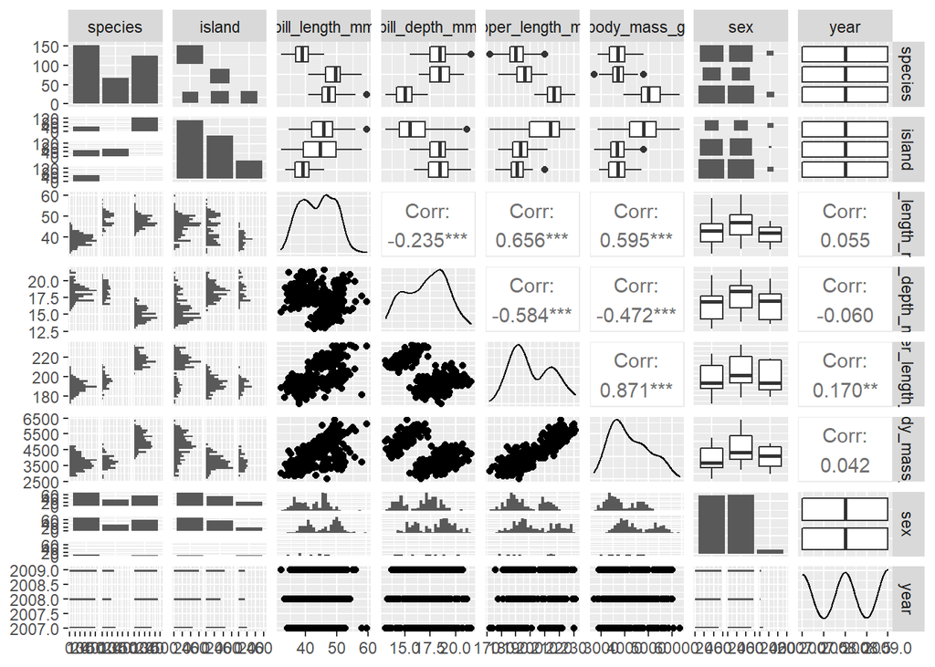

```r
ggpairs(penguins)
```

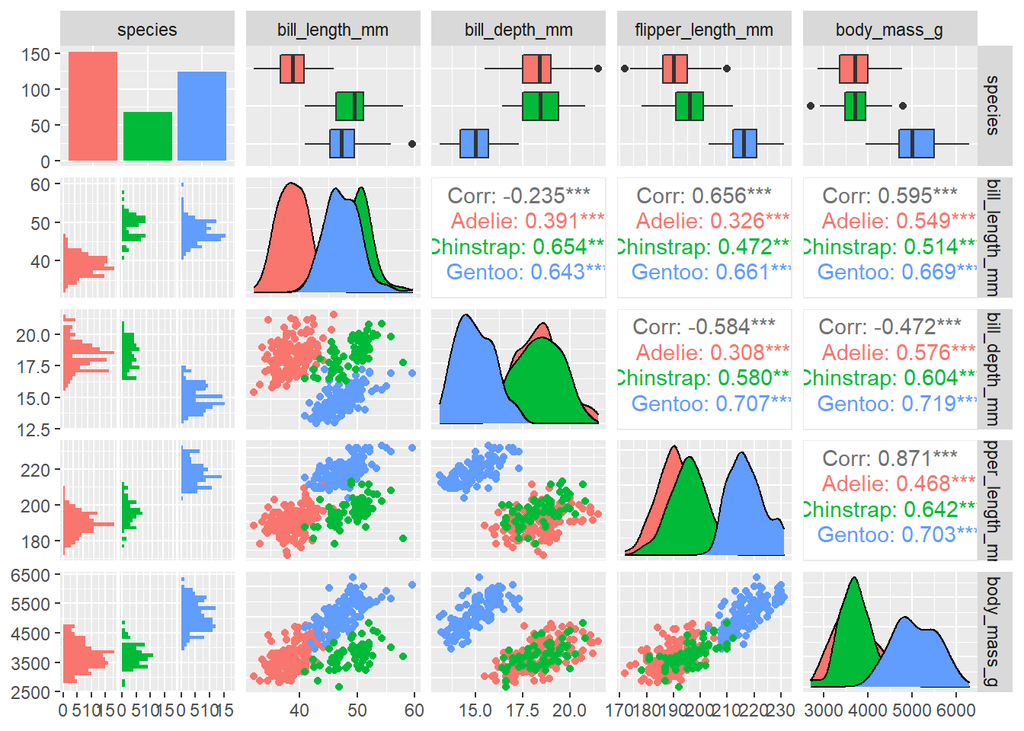

```r
penguins %>%
  select(species, bill_length_mm:body_mass_g) %>%
  ggpairs(aes(color = species))
```

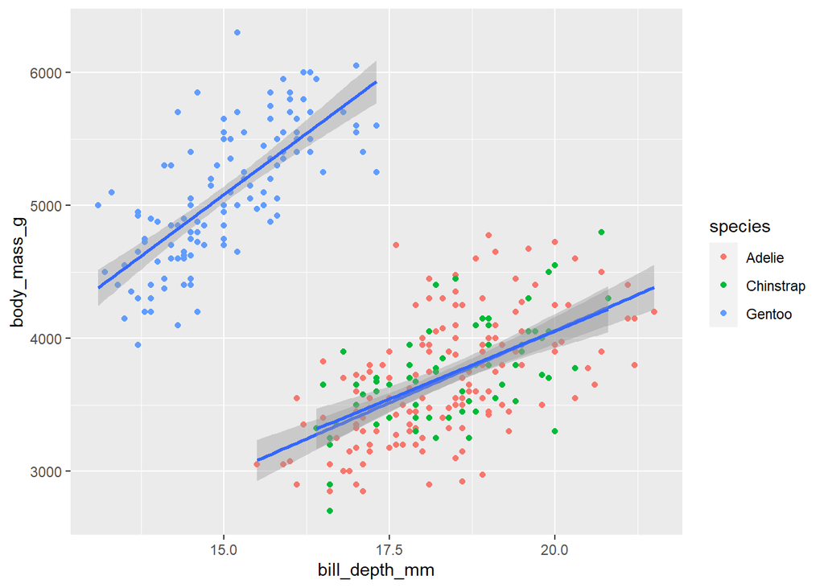

```r
ggplot(data= penguins, aes(x = bill_depth_mm, y = body_mass_g, group = species))+
  geom_point(aes(color = species))+
  geom_smooth(method = "lm")
```

multiple linear regression, penguins use multiple linear regression to try to understand the relationship between multiple predictor variables and a single continuous outcome variable(body mass)

```r
penguin_lm <- lm(body_mass_g ~ flipper_length_mm + bill_depth_mm, data = penguins)
penguin_lm
```

```
##
## Call:
## lm(formula = body_mass_g ~ flipper_length_mm + bill_depth_mm,
##     data = penguins)
##
## Coefficients:
##       (Intercept)  flipper_length_mm      bill_depth_mm
##          -6541.91              51.54              22.63
```

for every 1 mm increase in flipper length we can expect on average increase of 51.54g in body mass, considering all other variables remain constant

use the summary function to get more info

```r
summary(penguin_lm)
```

```
##
## Call:
## lm(formula = body_mass_g ~ flipper_length_mm + bill_depth_mm,
##     data = penguins)
##
## Residuals:
##      Min       1Q   Median       3Q      Max
## -1029.78  -271.45   -23.58   245.15  1275.97
##
## Coefficients:
##                    Estimate Std. Error t value Pr(>|t|)
## (Intercept)       -6541.907    540.751 -12.098   <2e-16 ***
## flipper_length_mm    51.541      1.865  27.635   <2e-16 ***
## bill_depth_mm        22.634     13.280   1.704   0.0892 .
## ---
## Signif. codes:  0 '***' 0.001 '**' 0.01 '*' 0.05 '.' 0.1 ' ' 1
##
## Residual standard error: 393.2 on 339 degrees of freedom
##   (2 observations deleted due to missingness)
## Multiple R-squared:  0.761,  Adjusted R-squared:  0.7596
## F-statistic: 539.8 on 2 and 339 DF,  p-value: < 2.2e-16
```

adjusted R-squared: 75 percent of the varience in our penguin body mass is explained in this model. 24 percent in varience that is not explained by our model. not good or bad. just a number telling us how much is explained

p-value od 2.2e-16, yes this model is doing a better job including these variables

use broom functions tidy and glance

broom: get coefficient summary in a data frame broom::glance: get model summary in a data frame

```r
penguin_lm_tidy<- tidy(penguin_lm)
penguin_lm_tidy
```

```
## # A tibble: 3 x 5
##   term              estimate std.error statistic  p.value
##   <chr>                <dbl>     <dbl>     <dbl>    <dbl>
## 1 (Intercept)        -6542.     541.      -12.1  2.99e-28
## 2 flipper_length_mm     51.5      1.87     27.6  7.72e-89
## 3 bill_depth_mm         22.6     13.3       1.70 8.92e- 2
```

using in-line code to refer to bill depth coefficient

22.6341385 put curser on it, hit cnrt, enter

```r
penguin_lm_glance <- glance(penguin_lm)
penguin_lm_glance
```

```
## # A tibble: 1 x 12
##   r.squared adj.r.squared sigma statistic   p.value    df logLik   AIC   BIC
##       <dbl>         <dbl> <dbl>     <dbl>     <dbl> <dbl>  <dbl> <dbl> <dbl>
## 1     0.761         0.760  393.      540. 4.23e-106     2 -2527. 5062. 5077.
## # ... with 3 more variables: deviance <dbl>, df.residual <int>, nobs <int>
```

## try another model

thought hard, did a lit review, consulted with experts, deeply explored data, decided three most critical variables to include are: flipper length species sex

```r
penguin_sex_species_lm <- lm(body_mass_g ~ flipper_length_mm + species + sex, data = penguins)
penguin_sex_species_lm_tidy<- tidy(penguin_sex_species_lm)
penguin_sex_species_lm_tidy
```

```
## # A tibble: 5 x 5
##   term              estimate std.error statistic  p.value
##   <chr>                <dbl>     <dbl>     <dbl>    <dbl>
## 1 (Intercept)         -366.     532.      -0.688 4.92e- 1
## 2 flipper_length_mm     20.0      2.85     7.04  1.15e-11
## 3 speciesChinstrap     -87.6     46.3     -1.89  5.95e- 2
## 4 speciesGentoo        836.      85.2      9.82  4.11e-20
## 5 sexmale              530.      37.8     14.0   2.41e-35
```

```r
penguin_sex_species_lm
```

```
##
## Call:
## lm(formula = body_mass_g ~ flipper_length_mm + species + sex,
##     data = penguins)
##
## Coefficients:
##       (Intercept)  flipper_length_mm   speciesChinstrap      speciesGentoo
##           -365.82              20.02             -87.63             836.26
##           sexmale
##            530.38
```

ref: adelle, female

use broom augment

```r
augment(penguin_sex_species_lm)
```

```
## # A tibble: 333 x 11
##    .rownames body_mass_g flipper_length_mm species sex    .fitted .resid    .hat
##    <chr>           <int>             <int> <fct>   <fct>    <dbl>  <dbl>   <dbl>
##  1 1                3750               181 Adelie  male     3789.  -39.1 0.0244
##  2 2                3800               186 Adelie  female   3359.  441.  0.00990
##  3 3                3250               195 Adelie  female   3539. -289.  0.0163
##  4 5                3450               193 Adelie  female   3499.  -49.0 0.0136
##  5 6                3650               190 Adelie  male     3969. -319.  0.0110
##  6 7                3625               181 Adelie  female   3259.  366.  0.0128
##  7 8                4675               195 Adelie  male     4069.  606.  0.0101
##  8 13               3200               182 Adelie  female   3279.  -78.7 0.0119
##  9 14               3800               191 Adelie  male     3989. -189.  0.0104
## 10 15               4400               198 Adelie  male     4129.  271.  0.0117
## # ... with 323 more rows, and 3 more variables: .sigma <dbl>, .cooksd <dbl>,
## #   .std.resid <dbl>
```

## use plot to look at model diagnostics

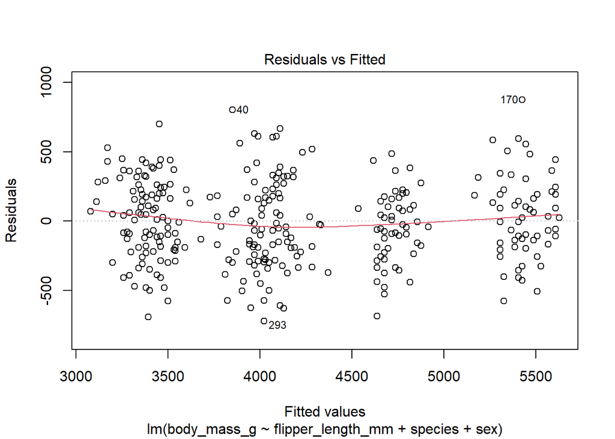

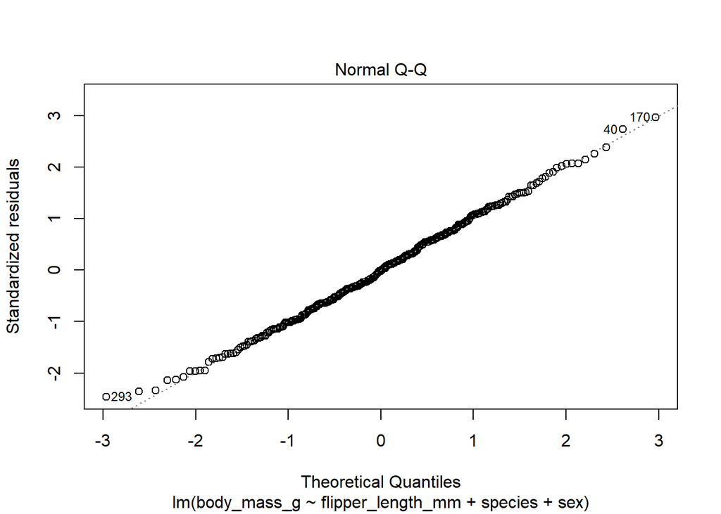

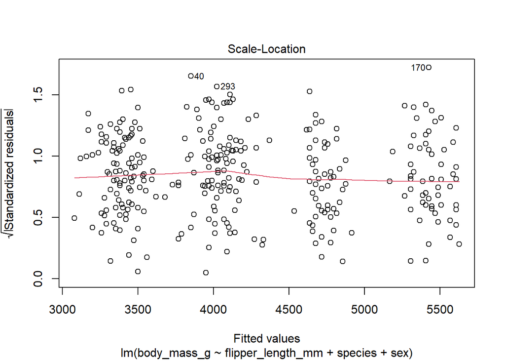

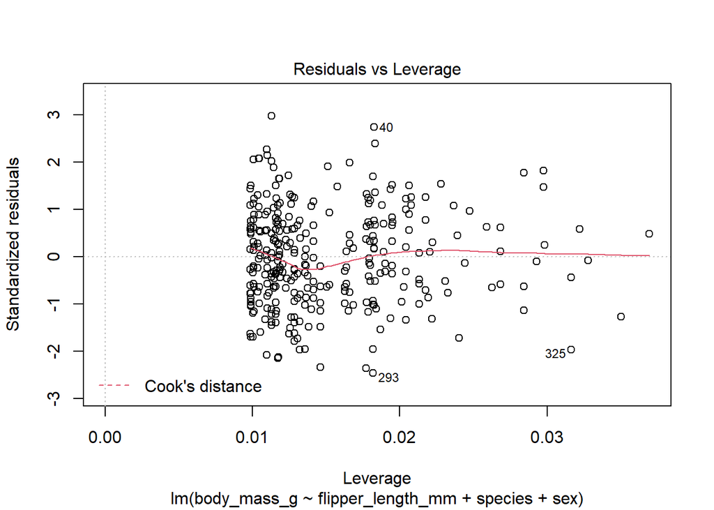

```r
plot(penguin_sex_species_lm)
```

conceptual understanding and expertise allows me to responsibly determine that penguin species, sex, and flipper length are reasonable predictor variable (make sure you think about variables and diff variable combinations) diagnostic plots all check out for normality of residuals, homoscedacity, and no worriesome outliers(<<last one is not an assumption)

##make output tables

```r
modelsummary(penguin_sex_species_lm)
```

|  | Model 1 |
| --- | --- |
| (Intercept) | -365.817 |
|  | (532.050) |
| flipper_length_mm | 20.025 |
|  | (2.846) |
| speciesChinstrap | -87.634 |
|  | (46.347) |
| speciesGentoo | 836.260 |
|  | (85.185) |
| sexmale | 530.381 |
|  | (37.810) |
| Num.Obs. | 333 |
| R2 | 0.867 |
| R2 Adj. | 0.865 |
| AIC | 4740.8 |
| BIC | 4763.6 |
| Log.Lik. | -2364.387 |
| F | 534.024 |

using stargazer….stick to model summary

```r
stargazer(penguin_sex_species_lm, type = "html")
```

|  | *Dependent variable:* |
| --- | --- |
|  | body_mass_g |
| flipper_length_mm | 20.025*** |
|  | (2.846) |
| speciesChinstrap | -87.634* |
|  | (46.347) |
| speciesGentoo | 836.260*** |
|  | (85.185) |
| sexmale | 530.381*** |
|  | (37.810) |
| Constant | -365.817 |
|  | (532.050) |
| Observations | 333 |
| R<sup>2</sup> | 0.867 |
| Adjusted R<sup>2</sup> | 0.865 |
| Residual Std. Error | 295.565 (df = 328) |
| F Statistic | 534.024*** (df = 4; 328) |
| *Note:* | p<0.1; p<0.05; p<0.01 |